# Data Lab 6 Modeling Point-Referenced Data

# Data Wrangling and Visualization

Specify working directory and load R data file.

```r
setwd ("Y:/Teaching/Bios737 Spatial Analysis/Lectures/SISMID Labs/P6")
load ("dat_krig.RData")
```

This time we have 2 data sets. First, *dat* contains the observed PM2.5 concentrations at 78 sites on a particularly day. We also have 4 spatial predictors: elevation, percent forest cover, highway len gth, and simulate PM2.5 level from a numerical model (The Community Multiscale Air Quality Modeling System, CMAQ). The predictors present values linked to a 12km x 12km grid cell that contains the monitor.

```r
str (dat)
```

```
## 'data.frame':    78 obs. of  7 variables:
##  $ pm_lat     : num  31.6 32.4 32.5 32.5 32.4 ...
##  $ pm_lon     : num  -84.1 -86.3 -85 -85 -84.9 ...
##  $ pm         : num  13.2 6.25 9.65 9.7 7.4 7.7 13.5 12.5 5.2 9.9 ...
##  $ elevation  : num  60.4 49.5 103.7 103.7 100.3 ...
##  $ forestcover: num  0.246 0.352 0.389 0.389 0.515 ...
##  $ hwy.length : num  20180 0 65347 65347 15936 ...
##  $ cmaq       : num  15.11 9.62 10.42 10.42 6.8 ...
```

The second data set, *dat.pred* contains information for prediction at 2,400 locations. The data set has the same structure but does not contain the variable *pm*.

```r
str (dat.pred)
```

```
## 'data.frame':    2400 obs. of  6 variables:
##  $ Lat        : num  31.6 31.6 31.6 31.6 31.6 ...
##  $ Lon        : num  -87.7 -87.6 -87.4 -87.3 -87.2 ...
##  $ elevation  : num  80.9 43.6 45.6 77 106.9 ...
##  $ forestcover: num  0.82 0.707 0.708 0.816 0.894 ...
##  $ hwy.length : num  25325 25325 0 0 0 ...
##  $ cmaq       : num  2.73 2.61 3.83 4.29 3.77 ...
```

We will first create *sf* objects and visualize the datasets.

```r
library (sf)
```

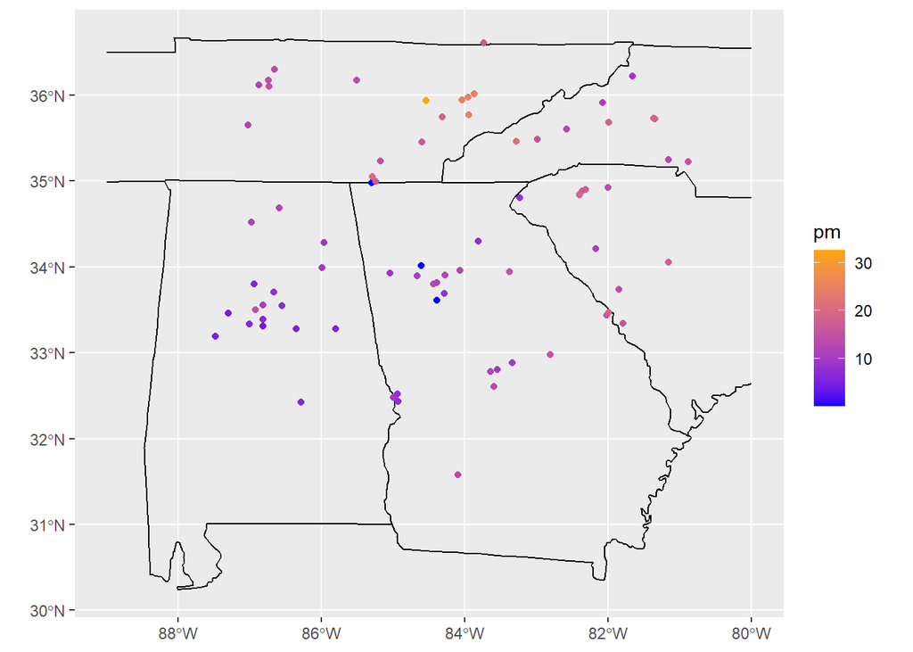

```r
library (ggplot2)
library (maps)
library (cowplot)

dat = st_as_sf(dat, coords = c("pm_lon","pm_lat"))
dat.pred = st_as_sf(dat.pred, coords = c("Lon","Lat"))
dat = st_set_crs(dat, 4979) #Set datum to WGS 84
dat.pred = st_set_crs(dat.pred, 4979)

#Create overlay state map
#Convert from map object to sf and keep only boundary lines
state.map = map ("state", region = c("alabama", "georgia", "south carolina", "north carolina", "tennessee"),fill = T,  plot = F)
state.map =  st_boundary(sf::st_as_sf(state.map))
state.map = st_crop(state.map, xmin = -89, xmax = -80, ymin = 30, ymax = 36.7)

#Visualize observed PM2.5 values at 78 locations
ggplot() + geom_sf (data = state.map)+
  geom_sf(aes(color=pm), size = 1.5, data=dat)+
  scale_color_gradient(low = "blue",high = "orange")
```

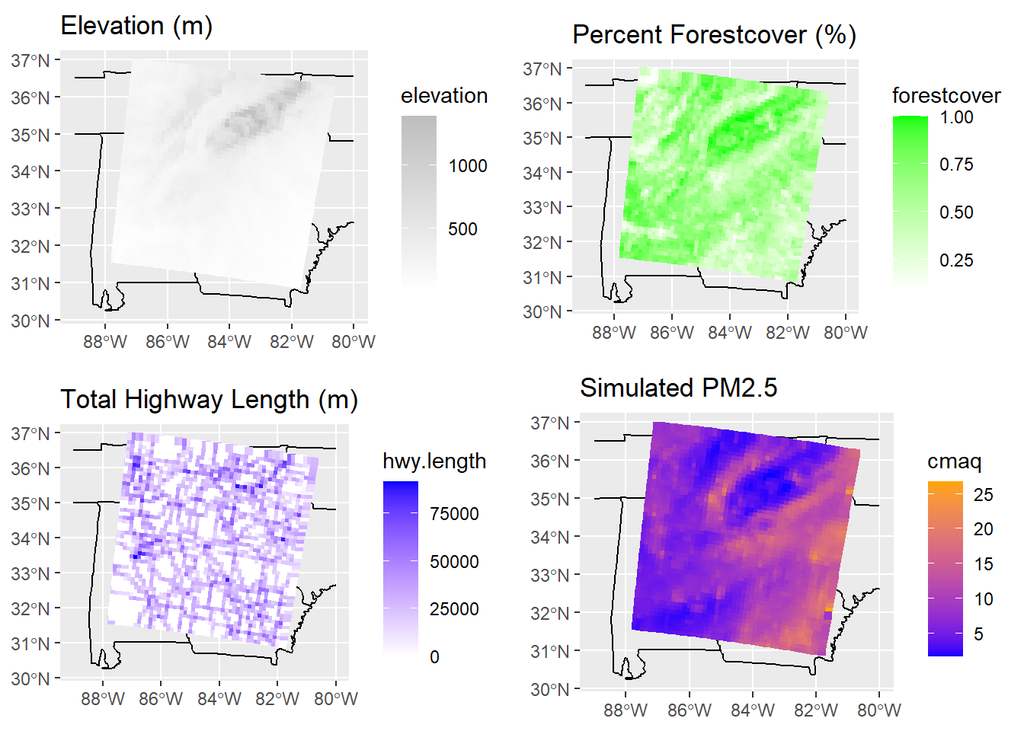

```r
#Visualize covariate values at 2,400 prediction locations
p1 = ggplot()  + geom_sf (data = state.map) +
  geom_sf(aes(color=elevation), size = 1.5, shape=15, data=dat.pred) +
  scale_color_gradient(low = "white",high = "grey")+ggtitle("Elevation (m)")
p2 = ggplot()  + geom_sf (data = state.map) +
  geom_sf(aes(color=forestcover), size = 1.5, shape=15, data=dat.pred) +
  scale_color_gradient(low = "white",high = "green")+ggtitle("Percent Forestcover (%)")
p3 = ggplot()  + geom_sf (data = state.map) +
  geom_sf(aes(color=hwy.length), size = 1.5, shape=15, data=dat.pred) +
  scale_color_gradient(low = "white",high = "blue")+ggtitle("Total Highway Length (m)")
p4 = ggplot()  + geom_sf (data = state.map) +
  geom_sf(aes(color=cmaq), size = 1.5, shape=15, data=dat.pred) +
  scale_color_gradient(low = "blue",high = "orange")+ggtitle("Simulated PM2.5")
plot_grid (p1, p2, p3, p4)
```

# Estimating Covariance Function Parameters

If we are willing to work under a parametric framework, assuming the outcome is Gaussian, then one approach is to use the likelihood to estimate **both** the regression coefficients and the covariance function parameters simultaneously. Likelihood-based methods, MLE or REML, are implemented using *likfit*. Here we use REML that also accounts for the fact that MLE estimates of variance parameters are slightly biased.

We need to specify:

- covariance model (cov.model = )
- initial values (ini.cov.pars = )
- estimation procedure (lik.method = “ML” or “REML”)
- spatial covariate (trend = ~ X1 + X2 + … )

We will restrict this analysis to the Gaussian (squared exponential) covariance function. Other commonly used options are exponential and Matern (with a specified smoothness, kappa parameter).

It’s good to give initial values to avoid convergence problems. We will usually try different initial values or estimate from variogram analysis (not covered here). Remember to project lat-lon coordinates to (x,y) in order to use Euclidean distances in the covariance function.

```r
library (geoR)
```

[output not shown]

[output not shown]

```r
#Project and convert from meters to km
dat.proj = st_transform(dat, crs = "ESRI:102004")
locs = as.matrix(st_coordinates(dat.proj)/1000)

#Gaussian Cov Fnc (no trend)
fit0 = likfit (coord=locs, data = dat$pm, cov.model = "gaussian",
               ini.cov.pars=c(15,  100), lik.met = "REML", message = F)

#Gaussian Cov Fnc (with CMAQ as predictor)
fit = likfit (coord=locs, data = dat$pm, cov.model = "gaussian",
               ini.cov.pars=c(15,  200),trend = (~dat$cmaq), lik.met = "REML", message = F )
```

With estimated parameter values, we can calculate the standard error of the fixed effects (see lecture). Let’s also examine how correlation decays as a function of distance from our estimated covariance function. One common statistic to measure how the correlation drops is the *effective range* defined as the distance where correlation is 0.05.

```r
## This function will take in a cov function, and return betas and their standard error
myfunc = function (X, Y, d.mat, model){
  nugget = model$nugget
  range = model$cov.pars[2]
  partial_sill = model$cov.pars[1]
  C = partial_sill*exp (-d.mat^2/(range^2))+nugget*diag(length(Y))
  beta.i = solve(t(X)%*%solve(C)%*%X)%*% t(X)%*%solve(C)%*%Y
  sd.i = sqrt (diag(solve(t(X)%*%solve(C)%*%X)))
  cbind (beta.i, sd.i)
}

d.mat = as.matrix(dist (locs)) #Distance matrix
myfunc (X = cbind (1, dat$cmaq), Y = dat$pm, d.mat, fit0)
```

```
##                     sd.i
## [1,] 9.0947055 2.5838815
## [2,] 0.3523313 0.1302291
```

```r
myfunc (X = matrix(rep(1,nrow(dat))), Y = dat$pm, d.mat, fit)
```

```
##                   sd.i
## [1,] 12.95876 1.847466
```

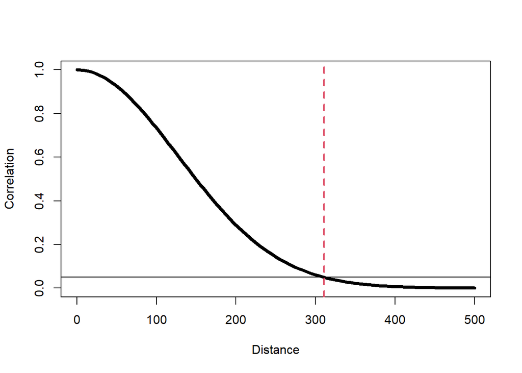

```r
##Correlation-distance plot
d = seq (0, 500, by = 5)
corr_dist = exp (-d^2/(fit$cov.pars[2]^2))
plot (corr_dist~d, type = "l", xlab = "Distance",  ylab = "Correlation", lwd = 4)
abline (v = sqrt (-log(0.05))*fit$cov.pars[2], col = 2, lty = 2, lwd = 2)
abline (h = 0.05)
```

# Kriging Prediction

Next, we will use geoR’s *krige.cov* function to perform prediction.The following inputs are needed: * locations for the observations (projected to x-y!) * outcome data (observations to be “conditioned” on) * locations for the predictions (projected to x-y!) * full specification of the covariance function (estimated from previous model fits)

We specify method = “OK” (ordinary kriging) to allow for covariates in the trend model.

```r
#Project the prediction locations
dat.pred.proj = st_transform(dat.pred, crs = "ESRI:102004")
locs.pred = as.matrix(st_coordinates(dat.pred.proj)/1000)

#No predictor kriging
fit_krig0 = krige.conv (coords = locs, data = dat$pm,
                       locations = locs.pred,
                       krige=krige.control (type.krige="OK",
                                            cov.model ="gaussian", cov.pars = c(18.9, 204), nugget = 15.6  ) )
```

```
## krige.conv: model with constant mean
## krige.conv: Kriging performed using global neighbourhood
```

```r
#Kriging with covariate (CMAQ)
fit_krig = krige.conv (coords = locs, data = dat$pm,
                       locations = locs.pred,
                       krige=krige.control (type.krige="OK",
                                            trend.d=trend.spatial(~cmaq, dat), trend.l=trend.spatial(~cmaq, dat.pred),  cov.model ="gaussian",cov.pars = c(16.4, 179), nugget = 13.4  ) )
```

```
## krige.conv: model with covariates matrix provided by the user
## krige.conv: Kriging performed using global neighbourhood
```

Predictions and their variance can be extracted from the fitted object. We see that without covariate the predicted surface is very smooth with high/low prediction values in regions with similar observed values.

```r
#Here is a list of values
names (fit_krig)
```

```
## [1] "predict"      "krige.var"    "beta.est"     "distribution" "message"
## [6] "call"
```

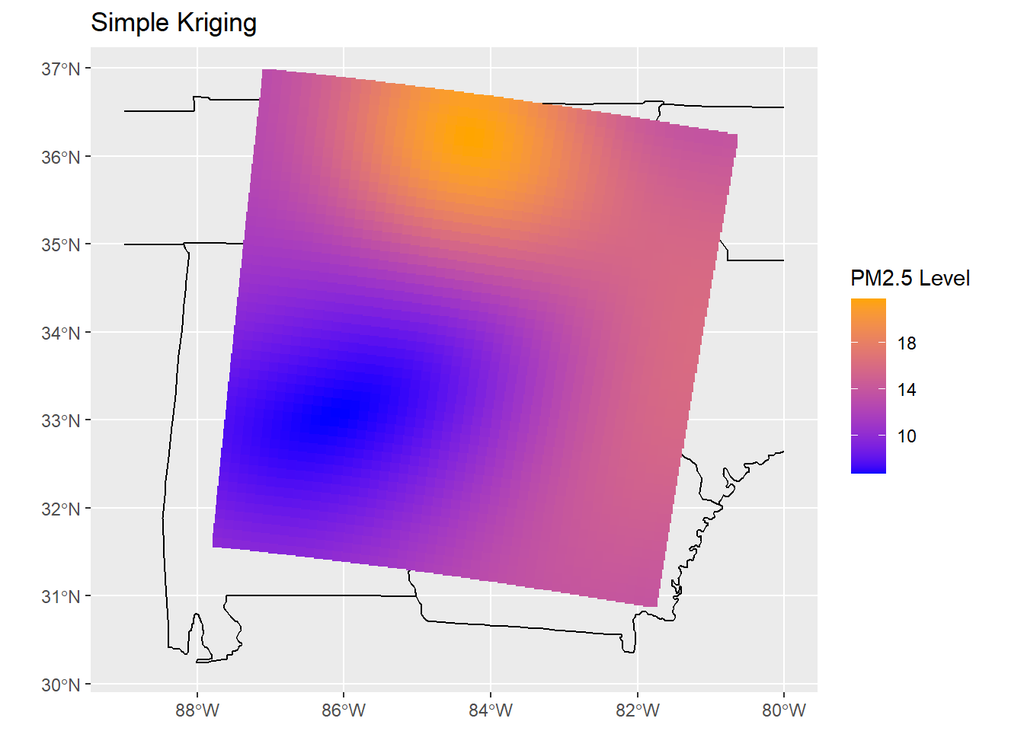

```r
#Put predictions and error in a nice dataframe
pred.results = data.frame (
  Est_fit0 = fit_krig0$predict,
  SE_fit0 = sqrt(fit_krig0$krige.var),
  Est_fit = fit_krig$predict,
  SE_fit = sqrt(fit_krig$krige.var))

#Make various prediction plots
ggplot()  + geom_sf (data = state.map) +
  geom_sf(aes(color=pred.results$Est_fit0), size = 3, shape=15, data=dat.pred) +  scale_color_gradient(low = "blue",high = "orange")+ggtitle("Simple Kriging")+labs(color = "PM2.5 Level")
```

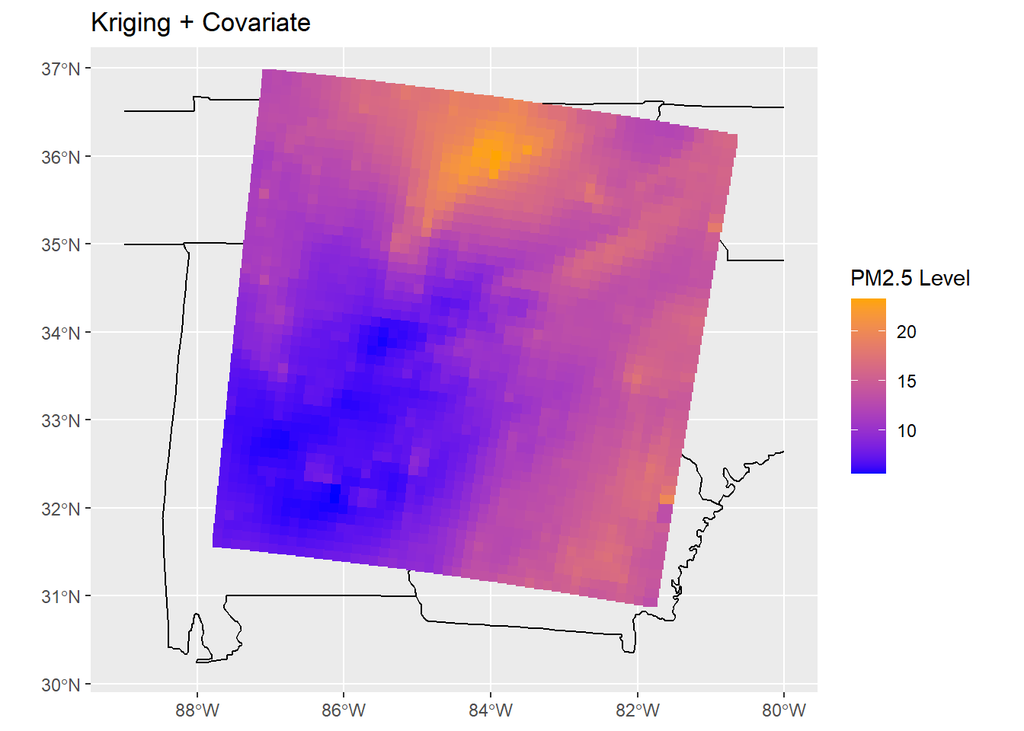

```r
ggplot()  + geom_sf (data = state.map) +
  geom_sf(aes(color=pred.results$Est_fit), size = 3, shape=15, data=dat.pred) +  scale_color_gradient(low = "blue",high = "orange")+ggtitle("Kriging + Covariate")+labs(color = "PM2.5 Level")
```

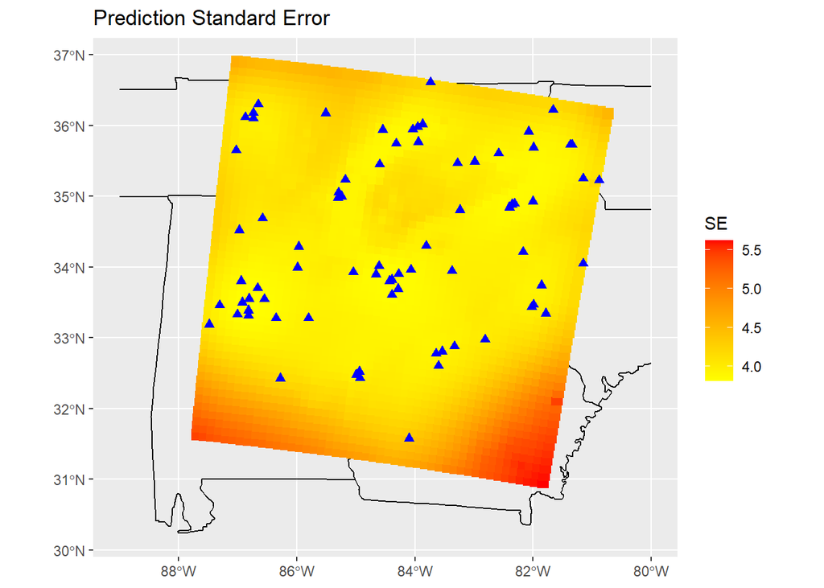

```r
u = as.matrix(st_coordinates(dat)) #Add observation locations
ggplot()  + geom_sf (data = state.map) +
  geom_sf(aes(color=pred.results$SE_fit), size = 3, shape=15, data=dat.pred) +  scale_color_gradient(low = "yellow",high = "red")+ggtitle("Prediction Standard Error")+labs(color = "SE")+geom_point(aes(u[,1], u[,2]), color = "blue", size = 2, shape =17)+ theme(axis.title.x=element_blank(),axis.title.y=element_blank())
```

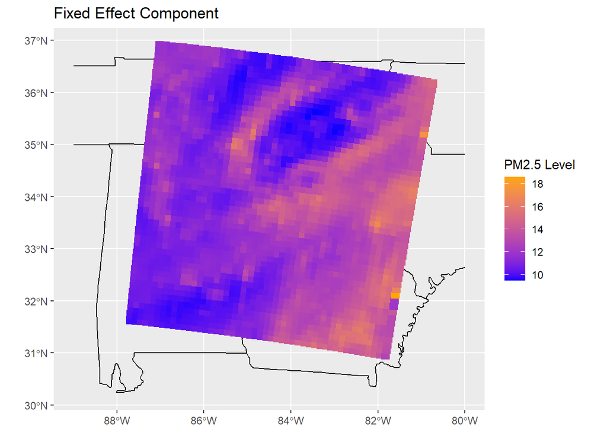

```r
#Decompose trend and spatial process
pred.results$Fixed = cbind (1, dat.pred$cmaq)%*%fit_krig$beta.est
pred.results$Smooth= pred.results$Est_fit0 - pred.results$Fixed

ggplot()  + geom_sf (data = state.map) +
  geom_sf(aes(color=pred.results$Fixed), size = 3, shape=15, data=dat.pred) +
  scale_color_gradient(low = "blue",high = "orange")+ggtitle("Fixed Effect Component")+labs(color = "PM2.5 Level")
```

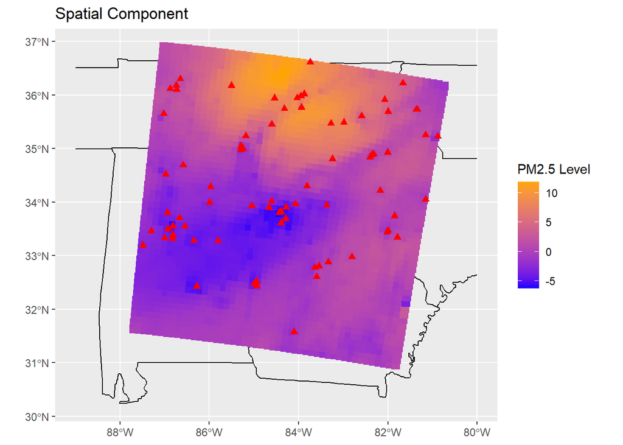

```r
ggplot()  + geom_sf (data = state.map) +
  geom_sf(aes(color=pred.results$Smooth), size = 3, shape=15, data=dat.pred) +
  scale_color_gradient(low = "blue",high = "orange")+ggtitle("Spatial Component")+labs(color = "PM2.5 Level")+geom_point(aes(u[,1], u[,2]), color = "red", size = 2, shape =17)+ theme(axis.title.x=element_blank(),axis.title.y=element_blank())
```

# Bayesian Kriging

geoR also support Bayesian kriging. There are a lot more arguments associated with estimation that one can specify. For some prior distributions, additional parameters (i.e. hyper-parameters) need to be specified. Also note that discretized or fixed values of $\phi$ is needed always.

Background and mathematical details can be found here: http://www.leg.ufpr.br/geoR/geoRdoc/bayeskrige.pdf

```r
fit_bayes = krige.bayes (coords = locs, data = dat$pm,
                   model=model.control (trend.d=~1+dat$cmaq, cov.model="gaussian"),
                   prior = prior.control(phi.prior = "uniform", phi.discrete=seq(1, 1000, by = 5),
                                         tausq.rel.discrete = seq(0.1, 10, by = 0.1),
                                         tausq.rel.prior=c("uniform")),
                   output = output.control(n.posterior = 5000, messages = FALSE) )
```

The function has several built in visualization to examine results.

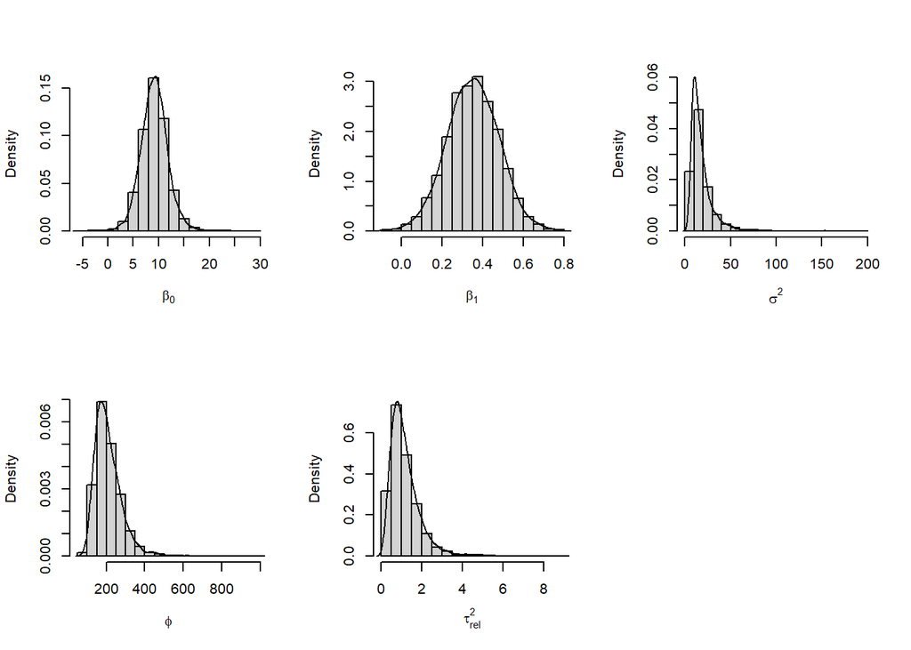

```r
##Histograms
par (mfrow = c(2,3))
hist (fit_bayes)

#Plot posterior versus prior distributions of the covariance parameters
par (mfrow = c(1,2))
```

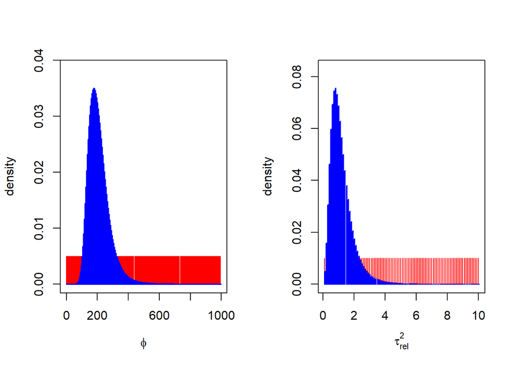

```r
plot(fit_bayes, type="h", col=c("red", "blue"))
```

We will also extract the posterior samples to calculate point and interval estimates. Recall that Bayesian inference via Markov chain Monte Carlo (MCMC) gives samples from the posterior distributions. We will use these samples for each parameter to calculate mean (point estimate) and interval (e.g., 2.5th and 97.5th quantiles).

```r
#Extract posterior samples
#This is matrix with num of rows = number of posterior samples
post.samp = fit_bayes$posterior$sample

#The column names are informative about the parameters
names (post.samp)
```

```
## [1] "beta0"     "beta1"     "sigmasq"   "phi"       "tausq.rel"
```

```r
#Because the model works with tau2/sigma2, we need to mannualy recover samples of tau2
post.samp$tau2 = post.samp$tausq.rel * post.samp$sigmasq

#Calculate posterior summary statistics and put ina nice table
Results = cbind (apply(post.samp,2,mean), apply(post.samp,2, median), apply (post.samp, 2, sd), apply (post.samp, 2, quantile, 0.025), apply(post.samp, 2, quantile, 0.975))
Results = as.data.frame (round(Results,2))
names (Results) = c("Mean", "Median", "SD", "2.5% Quantile", "97.5 Quantile")
Results
```

```
##             Mean Median    SD 2.5% Quantile 97.5 Quantile
## beta0       9.16   9.16  2.73          3.93         14.69
## beta1       0.35   0.35  0.13          0.10          0.60
## sigmasq    18.78  14.58 16.26          5.50         54.62
## phi       209.68 196.00 72.46        111.00        376.00
## tausq.rel   1.18   1.00  0.75          0.30          3.10
## tau2       15.37  15.05  3.05         10.45         22.66
```

```r
#Makes prediction only at 2 locations (row #1 and #820)
use.pred = c(1,820)

fit_bayes_pred = krige.bayes (coords = locs, data = dat$pm,
                              locations = locs.pred[use.pred,],
                   model=model.control (trend.d=~1+dat$cmaq, cov.model="gaussian",
                                        trend.l=~1+dat.pred$cmaq[use.pred]),
                   prior = prior.control(phi.prior = "uniform", phi.discrete=seq(1, 1000, by = 5),
                                         tausq.rel.discrete = seq(0.1, 10, by = 0.1),
                                         tausq.rel.prior=c("uniform")),
                   output = output.control(n.posterior = 5000, messages = FALSE) )

post.samp = t(fit_bayes_pred$predictive$simulations)

#By default krige.bayes gives the posterior samples of the spatial process. To get prediction of Y, we will need to add in the nugget. We first extract the posterior samples of sigma^2. Then generate a residual error for each sigma^2 and add it to the corresponding posterior predictive sample.
post.nugget = fit_bayes_pred$posterior$sample$sigmasq
post.samp[,1] = post.samp[,1] + rnorm (length (post.nugget), 0, sqrt(post.nugget))
post.samp[,2] = post.samp[,2] + rnorm (length (post.nugget), 0, sqrt(post.nugget))

##Calculate posterior mean, standard deviation, and 95% interval from Bayesian kriging
apply (post.samp, 2, mean)
```

```
## [1] 7.855186 6.990185
```

```r
apply (post.samp, 2, sd)
```

```
## [1] 5.775429 4.532698
```

```r
apply (post.samp, 2, quantile, c(0.025, 0.975))
```

```
##            [,1]      [,2]
## 2.5%  -4.122097 -1.862493
## 97.5% 18.933107 15.763315
```